# Apunte 1: La econometría y la regresión lineal

Econometría para la gestión · Ingeniería Comercial

Prof. Juan Pablo Carrasco

24 de agosto de 2026

# 1 Introducción a la Econometría

Bienvenidos al primer apunte de la asignatura. En el ámbito de la gestión y los negocios, la capacidad de **medir, modelar y pronosticar** el comportamiento de variables clave (ventas, costos, demanda, inflación, riesgo) es fundamental para la toma de decisiones estratégicas.

La **econometría** es la disciplina cuantitativa que combina:

1. **Teoría económica:** Plantea las relaciones causales e hipótesis cualitativas.
2. **Matemáticas:** Formula dichas relaciones en ecuaciones determinísticas.
3. **Inferencia estadística:** Permite contrastar los modelos con datos reales del mercado frente a la incertidumbre.

## 1.1 ¿Por qué estudiar Econometría en Ingeniería Comercial?

La econometría proporciona herramientas analíticas rigurosas para:

- **Evaluar relaciones causa-efecto:** Cuantificar el impacto marginal de una variable sobre otra (por ejemplo: *¿en cuánto aumentan los ingresos por cada peso adicional invertido en marketing digital?*).
- **Predecir escenarios:** Pronosticar la demanda futura bajo distintas condiciones macroeconómicas y de competencia.
- **Toma de decisiones basada en evidencia (*Data-Driven*):** Superar la simple intuición empresarial mediante análisis empírico validado.
- **Control y formulación de políticas internas:** Diseñar estructuras de precios y esquemas de incentivos óptimos.

# 2 ¿Qué es la Econometría?

De acuerdo con **Gujarati y Porter (2009)**, la econometría se define como:

> *“La aplicación de herramientas matemáticas y estadísticas a datos económicos con el fin de probar hipótesis, estimar relaciones y realizar pronósticos”* (p. 1).

Es fundamental no confundir la econometría con disciplinas afines:

## 2.1 Econometría vs. Estadística Económica

- **Estadística económica:** Se ocupa principalmente de la recolección, tabulación, procesamiento y presentación gráfica de cifras económicas (PIB, empleo, IPC). No busca verificar hipótesis causales de modelos teóricos.
- **Econometría:** Utiliza esos datos observados para estimar parámetros estructurales y contrastar si la teoría económica se cumple en la práctica.

## 2.2 Econometría vs. Economía Matemática

- **Economía matemática:** Expresa la teoría económica en forma de ecuaciones exactas (determinísticas), sin contrastarlas directamente con datos del mundo real.
- **Economía econométrica:** Reconoce que el comportamiento humano y los mercados no son determinísticos; por ello, incorpora la **aleatoriedad y el error** para estimar relaciones con datos reales.

📝 Autoevaluación 1: Conceptos Fundamentales

**Pregunta:** ¿Cuál es la principal diferencia entre la econometría y la estadística económica?

La econometría solo formula teorías sin usar datos, mientras que la estadística económica realiza pronósticos matemáticos. La estadística económica se enfoca en recopilar y describir datos; la econometría utiliza esos datos para probar hipótesis, medir impactos y pronosticar. La estadística económica asume causalidad estocástica y la econometría solo describe frecuencias observadas.

# 3 Metodología de la Investigación Econométrica

El proceso sistemático del análisis econométrico se compone de las siguientes etapas:

## 3.1 Planteamiento de la teoría o hipótesis

Se parte de un principio teórico. *Ejemplo:* La **Ley de la Demanda** postula que, *ceteris paribus*, existe una relación inversa entre el precio de un bien y la cantidad demandada.

## 3.2 Especificación del modelo matemático (Determinístico)

Se traduce la teoría a una formulación matemática exacta:

$$Q_d = \beta_0 + \beta_1 P$$

Donde:

- $Q_d$: Cantidad demandada.
- $P$: Precio del bien.
- $\beta_0$: Intercepto (demanda autónoma).
- $\beta_1$: Pendiente del modelo. Teóricamente se espera que $\beta_1 < 0$.

## 3.3 Especificación del modelo econométrico (Estocástico)

En la realidad, el precio no determina la demanda de manera exacta, y existen otros factores no observados. Por ende, se añade un **término de perturbación estocástica ($u_i$)**:

$$Q_{d,i} = \beta_0 + \beta_1 P_i +
u_i$$

Donde $u_i$ captura la influencia de variables omitidas (gustos, ingresos, clima), errores de medición y la aleatoriedad intrínseca del comportamiento humano.

## 3.4 Obtención de datos

Recolección de información cuantitativa mediante:

- **Corte transversal (*Cross-section*):** Múltiples individuos/empresas en un único momento del tiempo.
- **Series de tiempo (*Time series*):** Una misma variable observada a lo largo de periodos regulares (mensual, trimestral, anual).
- **Datos de panel (*Panel data*):** Combinación de corte transversal y series de tiempo.

## 3.5 Estimación de los parámetros

Aplicación del método de **Mínimos Cuadrados Ordinarios (MCO / OLS)** u otros estimadores para hallar los coeficientes numéricos $\hat{\beta}_0$ y $\hat{\beta}_1$.

## 3.6 Pruebas de hipótesis e inferencia

Verificación de significancia estadística ($t$-Student, $p$-values) e intervalos de confianza para comprobar si la evidencia empírica respalda el signo y magnitud esperados por la teoría.

## 3.7 Pronóstico y predicción

Utilización del modelo ajustado ($\hat{Q}_d = \hat{\beta}_0 + \hat{\beta}_1 P$) para prever el nivel de demanda ante fijaciones de precios futuras.

## 3.8 Uso del modelo para la toma de decisiones

Implementación de conclusiones en la estrategia de negocios: fijación de precios (*pricing*), planificación de inventarios o dimensionamiento de capacidad productiva.

📝 Autoevaluación 2: El Modelo Econométrico

**Pregunta:** ¿Por qué es indispensable incluir el término de error estocástico ($u$) al pasar de un modelo matemático a un modelo econométrico?

Porque asegura que el coeficiente $\beta_1$ sea siempre positivo. Porque permite convertir una muestra pequeña en una población infinita. Porque captura factores no observables o excluidos, errores de medición y la variabilidad aleatoria inherente a la conducta humana.

# 4 Aplicaciones de la Econometría en la Gestión Empresarial

| Área de Aplicación | Problema de Decisión | Modelo Econométrico Típico |
| --- | --- | --- |
| **Pricing y Demanda** | Determinar la elasticidad precio para maximizar ingresos. | Regresión log-log ($\ln Q = \beta_0 + \beta_1 \ln P + u$) |
| **Marketing** | Medir el Retorno sobre la Inversión (ROI) de campañas publicitarias. | Regresión múltiple con variables de gasto en medios |
| **Finanzas** | Estimar el riesgo sistemático ($\beta$) de una acción (Modelo CAPM). | Regresión lineal simple entre retornos |
| **Recursos Humanos** | Evaluar la brecha salarial por nivel educativo o experiencia. | Ecuación de Mincer con variables *dummy* |

# 5 Ejemplo Práctico en R: Estimación de Ventas y Publicidad

A continuación, estimaremos un modelo de regresión lineal simple para evaluar cómo el gasto publicitario ($X$) impacta en las ventas ($Y$) de una empresa.

$$Ventas_i = \beta_0 + \beta_1
Publicidad_i + u_i$$

```r
# 1. Creación de datos muestrales (en miles de USD)
datos_empresa <- data.frame(
  publicidad = c(10, 15, 12, 18, 20, 17, 22, 25),
  ventas     = c(100, 120, 110, 130, 150, 140, 165, 180)
)

# 2. Ajuste del modelo de Mínimos Cuadrados Ordinarios (MCO)
modelo_ventas <- lm(ventas ~ publicidad, data = datos_empresa)

# 3. Resumen de resultados estadísticos
summary(modelo_ventas)
```

```
##
## Call:
## lm(formula = ventas ~ publicidad, data = datos_empresa)
##
## Residuals:
##     Min      1Q  Median      3Q     Max
## -10.231  -1.758   2.084   2.867   5.139
##
## Coefficients:
##             Estimate Std. Error t value Pr(>|t|)
## (Intercept)  43.5785     7.3492    5.93  0.00103 **
## publicidad    5.3696     0.4084   13.15 1.19e-05 ***
## ---
## Signif. codes:  0 '***' 0.001 '**' 0.01 '*' 0.05 '.' 0.1 ' ' 1
##
## Residual standard error: 5.416 on 6 degrees of freedom
## Multiple R-squared:  0.9665, Adjusted R-squared:  0.9609
## F-statistic: 172.9 on 1 and 6 DF,  p-value: 1.194e-05
```

## 5.1 Visualización del Modelo

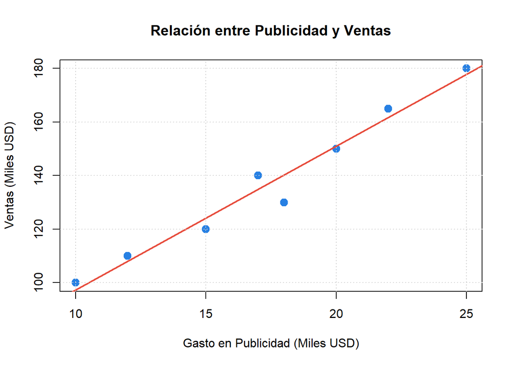

Ajuste de la recta de regresión MCO

```r
# Gráfico de dispersión y recta estimada
plot(datos_empresa$publicidad, datos_empresa$ventas,
     pch = 19, col = "#2780e3", cex = 1.4,
     main = "Relación entre Publicidad y Ventas",
     xlab = "Gasto en Publicidad (Miles USD)",
     ylab = "Ventas (Miles USD)")

# Agregar la recta de regresión
abline(modelo_ventas, col = "#e74c3c", lwd = 2)
grid()
```

# 6 Referencias Bibliográficas

- **Gujarati, D. N., & Porter, D. C. (2009).** *Econometría Básica* (5.ª ed.). McGraw-Hill Interamericana.
- **Wooldridge, J. M. (2015).** *Introducción a la econometría: Un enfoque moderno* (5.ª ed.). Cengage Learning.
- **Stock, J. H., & Watson, M. W. (2012).** *Introducción a la Econometría* (3.ª ed.). Pearson Educación.